# Борисов С. Домашнее задание «Дерево CHAID»

## 1. Загрузка данных

```r
data <- read.csv2("Response.csv", sep=";")
head(data, 10)
```

|  | mortgage | life_ins | cre_card | deb_card | mob_bank | curr_acc | internet | perloan | savings | atm_user | markpl | age | cus_leng | response |
| --- | --- | --- | --- | --- | --- | --- | --- | --- | --- | --- | --- | --- | --- | --- |
| 1 | 0 | 0 | 0 | 0 | 0 | 0 | 0 | 0 | 0 | 0 | 0 | 18 | 1 | 0 |
| 2 | 1 | 1 | 0 | 1 | 1 | 0 | 0 | 0 | 0 | 1 | 0 | 18 | 2 | 1 |
| 3 | 1 | 1 | 0 | 1 | 0 | 0 | 0 | 0 | 0 | 0 | 1 | 18 | 2 | 1 |
| 4 | 1 | 1 | 1 | 1 | 0 | 1 | 0 | 0 | 0 | 1 | 1 | 18 | 2 | 1 |
| 5 | 1 | 1 | 0 | 1 | 0 | 0 | 0 | 1 | 0 | 1 | 0 | 18 | 2 | 0 |
| 6 | 0 | 0 | 0 | 1 | 1 | 1 | 0 | 0 | 0 | 0 | 0 | 18 | 2 | 1 |
| 7 | 0 | 0 | 0 | 1 | 0 | 0 | 0 | 0 | 0 | 1 | 0 | 18 | 1 | 1 |
| 8 | 1 | 1 | 0 | 1 | 0 | 0 | 0 | 0 | 0 | 1 | 0 | 18 | 1 | 1 |
| 9 | 1 | 1 | 0 | 1 | 0 | 0 | 0 | 0 | 0 | 1 | 1 | 18 | 3 | 0 |
| 10 | 1 | 1 | 1 | 1 | 0 | 1 | 0 | 0 | 0 | 0 | 0 | 18 | 2 | 1 |

Расшифровка переменных

- номинальный предиктор Ипотечный кредит [mortgage];
- номинальный предиктор Страхование жизни [life_ins];
- номинальный предиктор Кредитная карта [cre_card];
- номинальный предиктор Дебетовая карта [deb_card];
- номинальный предиктор Мобильный банк [mob_bank];
- номинальный предиктор Текущий счет [curr_acc];
- номинальный предиктор Интернет-доступ к счету [internet];
- номинальный предиктор Индивидуальный займ [perloan];
- номинальный предиктор Наличие сбережений [savings];
- номинальный предиктор Пользование банкоматом за последнюю неделю [atm_user];
- номинальный предиктор Пользование услугами онлайн-маркетплейса за последний месяц [markpl];
- количественный предиктор Возраст [age];
- порядковый предиктор Давность клиентской истории [cus_leng];
- номинальная зависимая переменная Отклик на предложение новой карты [response]

Выводим количество пропусков:

```r
sum(is.na(data))
```

```
[1] 0
```

```r
data[!complete.cases(data),]
```

| mortgage | life_ins | cre_card | deb_card | mob_bank | curr_acc | internet | perloan | savings | atm_user | markpl | age | cus_leng | response |
| --- | --- | --- | --- | --- | --- | --- | --- | --- | --- | --- | --- | --- | --- |

Пропусков нет.

Смотрим типы переменных:

```r
str(data)
```

```
'data.frame':   30259 obs. of  14 variables:
 $ mortgage: int  0 1 1 1 1 0 0 1 1 1 ...
 $ life_ins: int  0 1 1 1 1 0 0 1 1 1 ...
 $ cre_card: int  0 0 0 1 0 0 0 0 0 1 ...
 $ deb_card: int  0 1 1 1 1 1 1 1 1 1 ...
 $ mob_bank: int  0 1 0 0 0 1 0 0 0 0 ...
 $ curr_acc: int  0 0 0 1 0 1 0 0 0 1 ...
 $ internet: int  0 0 0 0 0 0 0 0 0 0 ...
 $ perloan : int  0 0 0 0 1 0 0 0 0 0 ...
 $ savings : int  0 0 0 0 0 0 0 0 0 0 ...
 $ atm_user: int  0 1 0 1 1 0 1 1 1 0 ...
 $ markpl  : int  0 0 1 1 0 0 0 0 1 0 ...
 $ age     : int  18 18 18 18 18 18 18 18 18 18 ...
 $ cus_leng: int  1 2 2 2 2 2 1 1 3 2 ...
 $ response: int  0 1 1 1 0 1 1 1 0 1 ...
```

## 2. Изменение типов переменных

Преобразовываем зависимую переменную Отклик (response) в вектор типа factor:

```r
data$response <- as.factor(data$response)
```

Преобразовываем порядковый предиктор Давность клиентской истории [cus_leng] в вектор типа ordered factor

```r
data$cus_leng <- ordered(data$cus_leng,
                         levels = c("1", "2", "3"))
```

Преобразовываем количественный предиктор Возраст [age] в вектор типа numeric:

```r
data$age <- as.numeric(data$age)
```

преобразовываем все номинальные предикторы в вектора типа factor

```r
data[] <- lapply(data, function(x) if(is.integer(x)) as.factor(x) else x)
```

```r
library(dplyr)
data$response <- recode(data$response, "0"="Нет", "1"="Да")
```

Смотрим типы переменных:

```r
str(data)
```

```
'data.frame':   30259 obs. of  14 variables:
 $ mortgage: Factor w/ 2 levels "0","1": 1 2 2 2 2 1 1 2 2 2 ...
 $ life_ins: Factor w/ 2 levels "0","1": 1 2 2 2 2 1 1 2 2 2 ...
 $ cre_card: Factor w/ 2 levels "0","1": 1 1 1 2 1 1 1 1 1 2 ...
 $ deb_card: Factor w/ 2 levels "0","1": 1 2 2 2 2 2 2 2 2 2 ...
 $ mob_bank: Factor w/ 2 levels "0","1": 1 2 1 1 1 2 1 1 1 1 ...
 $ curr_acc: Factor w/ 2 levels "0","1": 1 1 1 2 1 2 1 1 1 2 ...
 $ internet: Factor w/ 2 levels "0","1": 1 1 1 1 1 1 1 1 1 1 ...
 $ perloan : Factor w/ 2 levels "0","1": 1 1 1 1 2 1 1 1 1 1 ...
 $ savings : Factor w/ 2 levels "0","1": 1 1 1 1 1 1 1 1 1 1 ...
 $ atm_user: Factor w/ 2 levels "0","1": 1 2 1 2 2 1 2 2 2 1 ...
 $ markpl  : Factor w/ 2 levels "0","1": 1 1 2 2 1 1 1 1 2 1 ...
 $ age     : num  18 18 18 18 18 18 18 18 18 18 ...
 $ cus_leng: Ord.factor w/ 3 levels "1"<"2"<"3": 1 2 2 2 2 2 1 1 3 2 ...
 $ response: Factor w/ 2 levels "Нет","Да": 1 2 2 2 1 2 2 2 1 2 ...
```

смотрим дублирующиеся наблюдения

```r
data[duplicated(data),]
```

|  | mortgage | life_ins | cre_card | deb_card | mob_bank | curr_acc | internet | perloan | savings | atm_user | markpl | age | cus_leng | response |
| --- | --- | --- | --- | --- | --- | --- | --- | --- | --- | --- | --- | --- | --- | --- |
| 11 | 1 | 1 | 0 | 1 | 0 | 0 | 0 | 0 | 0 | 1 | 0 | 18 | 1 | Да |
| 20 | 1 | 1 | 0 | 1 | 0 | 1 | 0 | 0 | 0 | 0 | 1 | 18 | 2 | Да |
| 26 | 1 | 1 | 0 | 0 | 0 | 0 | 0 | 0 | 0 | 1 | 1 | 18 | 2 | Нет |
| 30 | 1 | 1 | 0 | 1 | 1 | 1 | 0 | 0 | 0 | 1 | 0 | 18 | 1 | Да |
| 32 | 1 | 1 | 0 | 1 | 0 | 0 | 0 | 0 | 0 | 1 | 0 | 18 | 1 | Да |
| 36 | 1 | 1 | 1 | 0 | 0 | 0 | 0 | 0 | 0 | 0 | 1 | 18 | 2 | Да |
| 38 | 1 | 1 | 1 | 1 | 0 | 0 | 0 | 0 | 0 | 1 | 1 | 18 | 2 | Да |
| 40 | 1 | 1 | 1 | 0 | 0 | 1 | 0 | 0 | 0 | 1 | 1 | 18 | 2 | Нет |
| 47 | 1 | 1 | 1 | 1 | 0 | 0 | 0 | 0 | 0 | 1 | 1 | 18 | 2 | Нет |
| 50 | 1 | 1 | 0 | 1 | 0 | 0 | 0 | 0 | 0 | 1 | 1 | 18 | 2 | Да |

[output cut: 990 more lines]

Оставим только уникальные наблюдения

```r
data <- unique(data)
# смотрим, сколько наблюдений мы теперь будем использовать
nrow(data)
```

```
[1] 14036
```

## 3. Обработка редких категорий

выводим информацию о распределении значений переменной cus_leng

```r
summary(data$cus_leng)
```

```
   1    2    3
3883 7874 2279
```

объектов со значением 2 больше, чем 1 и 3. Но редких категорий не наблюдается

## 4. Однократное случайное разбиение набора данных на обучающую и контрольную выборки для проверки модели

```r
set.seed(42)
data$random_number <- runif(nrow(data),0,1)
development <- data[ which(data$random_number > 0.3), ]
holdout <- data[ which(data$random_number <= 0.3), ]
data$random_number <- NULL
development$random_number <- NULL
holdout$random_number <- NULL
```

смотрим обучающий датафрейм

```r
str(development)
```

```
'data.frame':   9821 obs. of  14 variables:
 $ mortgage: Factor w/ 2 levels "0","1": 1 2 2 2 1 1 2 2 2 2 ...
 $ life_ins: Factor w/ 2 levels "0","1": 1 2 2 2 1 1 2 2 2 2 ...
 $ cre_card: Factor w/ 2 levels "0","1": 1 1 2 1 1 1 1 2 1 1 ...
 $ deb_card: Factor w/ 2 levels "0","1": 1 2 2 2 2 2 2 2 2 2 ...
 $ mob_bank: Factor w/ 2 levels "0","1": 1 2 1 1 2 1 1 1 1 1 ...
 $ curr_acc: Factor w/ 2 levels "0","1": 1 1 2 1 2 1 1 2 1 1 ...
 $ internet: Factor w/ 2 levels "0","1": 1 1 1 1 1 1 1 1 1 1 ...
 $ perloan : Factor w/ 2 levels "0","1": 1 1 1 2 1 1 1 1 1 1 ...
 $ savings : Factor w/ 2 levels "0","1": 1 1 1 1 1 1 1 1 1 1 ...
 $ atm_user: Factor w/ 2 levels "0","1": 1 2 2 2 1 2 2 1 1 1 ...
 $ markpl  : Factor w/ 2 levels "0","1": 1 1 2 1 1 1 2 1 1 1 ...
 $ age     : num  18 18 18 18 18 18 18 18 18 18 ...
 $ cus_leng: Ord.factor w/ 3 levels "1"<"2"<"3": 1 2 2 2 2 1 3 2 2 1 ...
 $ response: Factor w/ 2 levels "Нет","Да": 1 2 2 1 2 2 1 2 2 2 ...
```

смотрим контрольный датафрейм

```r
str(holdout)
```

```
'data.frame':   4215 obs. of  14 variables:
 $ mortgage: Factor w/ 2 levels "0","1": 2 2 2 1 2 2 2 2 1 1 ...
 $ life_ins: Factor w/ 2 levels "0","1": 2 2 2 2 2 2 2 2 2 1 ...
 $ cre_card: Factor w/ 2 levels "0","1": 1 1 2 1 2 2 1 1 1 2 ...
 $ deb_card: Factor w/ 2 levels "0","1": 2 2 1 2 2 2 2 2 2 2 ...
 $ mob_bank: Factor w/ 2 levels "0","1": 1 1 1 1 1 1 2 1 2 1 ...
 $ curr_acc: Factor w/ 2 levels "0","1": 1 1 1 1 1 1 1 1 1 2 ...
 $ internet: Factor w/ 2 levels "0","1": 1 1 1 1 1 1 1 1 1 1 ...
 $ perloan : Factor w/ 2 levels "0","1": 1 1 1 1 1 1 1 1 1 2 ...
 $ savings : Factor w/ 2 levels "0","1": 1 1 1 1 1 1 1 1 1 1 ...
 $ atm_user: Factor w/ 2 levels "0","1": 1 2 2 1 2 2 2 2 2 2 ...
 $ markpl  : Factor w/ 2 levels "0","1": 2 1 2 1 2 2 2 2 1 1 ...
 $ age     : num  18 18 18 18 18 18 18 18 18 18 ...
 $ cus_leng: Ord.factor w/ 3 levels "1"<"2"<"3": 2 1 2 1 2 2 2 1 1 2 ...
 $ response: Factor w/ 2 levels "Нет","Да": 2 2 1 2 1 2 2 2 2 1 ...
```

выводим информацию о распределении классов зависимой переменной response в обучающей выборке

```r
summary(development$response)
```

```
 Нет   Да
4252 5569
```

выводим информацию о распределении классов зависимой переменной response в контрольной выборке

```r
summary(holdout$response)
```

```
 Нет   Да
1831 2384
```

## 5. Биннинг количественных переменных для получения порядковых предикторов

выводим диапазон значений переменной age

```r
range(development$age)
```

```
[1] 18 63
```

разбиваем переменную age на 9 интервалов одинаковой ширины

```r
development$binned <-cut(x=development$age, breaks=seq(18, 63, by=5),
                         include.lowest=TRUE, right=TRUE,
                         ordered_result=TRUE, dig.lab = 0)
```

смотрим распределение значений переменной binned

```r
summary(development$binned)
```

```
[18,23] (23,28] (28,33] (33,38] (38,43] (43,48] (48,53] (53,58] (58,63]
    405     747    1521    1568    1569    1412    1345     695     559
```

с помощью функции quantileCut пакета lsr разбиваем переменную age на 10 интервалов c одинаковым количеством наблюдений

```r
library(lsr)
development$binned2 <- quantileCut(x=development$age, n=10,
                                   include.lowest=TRUE, right=TRUE,
                                   ordered_result=TRUE, dig.lab=0)
detach("package:lsr", unload=TRUE)
```

смотрим распределение значений переменной binned2

```r
summary(development$binned2)
```

```
[18,28] (28,31] (31,34] (34,37] (37,41] (41,44] (44,47] (47,51] (51,55] (55,63]
   1152     908     922     973    1247     925     836    1070     894     894
```

смотрим типы переменных

```r
str(development)
```

```
'data.frame':   9821 obs. of  16 variables:
 $ mortgage: Factor w/ 2 levels "0","1": 1 2 2 2 1 1 2 2 2 2 ...
 $ life_ins: Factor w/ 2 levels "0","1": 1 2 2 2 1 1 2 2 2 2 ...
 $ cre_card: Factor w/ 2 levels "0","1": 1 1 2 1 1 1 1 2 1 1 ...
 $ deb_card: Factor w/ 2 levels "0","1": 1 2 2 2 2 2 2 2 2 2 ...
 $ mob_bank: Factor w/ 2 levels "0","1": 1 2 1 1 2 1 1 1 1 1 ...
 $ curr_acc: Factor w/ 2 levels "0","1": 1 1 2 1 2 1 1 2 1 1 ...
 $ internet: Factor w/ 2 levels "0","1": 1 1 1 1 1 1 1 1 1 1 ...
 $ perloan : Factor w/ 2 levels "0","1": 1 1 1 2 1 1 1 1 1 1 ...
 $ savings : Factor w/ 2 levels "0","1": 1 1 1 1 1 1 1 1 1 1 ...
 $ atm_user: Factor w/ 2 levels "0","1": 1 2 2 2 1 2 2 1 1 1 ...
 $ markpl  : Factor w/ 2 levels "0","1": 1 1 2 1 1 1 2 1 1 1 ...
 $ age     : num  18 18 18 18 18 18 18 18 18 18 ...
 $ cus_leng: Ord.factor w/ 3 levels "1"<"2"<"3": 1 2 2 2 2 1 3 2 2 1 ...
 $ response: Factor w/ 2 levels "Нет","Да": 1 2 2 1 2 2 1 2 2 2 ...
 $ binned  : Ord.factor w/ 9 levels "[18,23]"<"(23,28]"<..: 1 1 1 1 1 1 1 1 1 1 ...
 $ binned2 : Ord.factor w/ 10 levels "[18,28]"<"(28,31]"<..: 1 1 1 1 1 1 1 1 1 1 ...
```

удаляем только что созданные переменные

```r
development$binned <- NULL
development$binned2 <- NULL
```

выполняем биннинг с учетом полученных правил разбиения

```r
development$age <-cut(x=development$age,
                         breaks=c(18,28,31,34,
                                  37,41,44,47,
                                  51,55,63,+Inf),
                         include.lowest=TRUE,
                         ordered_result=TRUE)
holdout$age <-cut(x=holdout$age,
                          breaks=c(18,28,31,34,
                                   37,41,44,47,
                                   51,55,63,+Inf),
                          include.lowest=TRUE,
                          ordered_result=TRUE)
```

## 6. Построение модели дерева CHAID и ее проверка

[figure not shown]

```r
library(CHAID)
# задаем набор условий для построения дерева CHAID
params <- chaid_control(minprob = 0.01, minsplit = 1000, minbucket = 500)
# строим модель дерева CHAID
chd  <- chaid(response ~ ., control = params, development)
# выводим диаграмму дерева
plot(chd)
```

```r
# выводим диаграмму дерева
# в схематичном виде
print(chd)
```

```
Model formula:
response ~ mortgage + life_ins + cre_card + deb_card + mob_bank +
    curr_acc + internet + perloan + savings + atm_user + markpl +
    age + cus_leng

Fitted party:
[1] root
|   [2] cus_leng in 1
|   |   [3] atm_user in 0
|   |   |   [4] mortgage in 0: Да (n = 873, err = 4.0%)
|   |   |   [5] mortgage in 1: Да (n = 713, err = 10.9%)
|   |   [6] atm_user in 1
|   |   |   [7] curr_acc in 0: Да (n = 391, err = 8.4%)
|   |   |   [8] curr_acc in 1: Да (n = 745, err = 30.3%)
|   [9] cus_leng in 2
|   |   [10] age in [18,28]: Да (n = 588, err = 30.1%)
|   |   [11] age in (28,31], (31,34]: Да (n = 969, err = 35.1%)
|   |   [12] age in (34,37], (37,41], (41,44]
|   |   |   [13] atm_user in 0: Да (n = 944, err = 31.8%)
|   |   |   [14] atm_user in 1: Нет (n = 814, err = 49.9%)
|   |   [15] age in (44,47], (47,51], (51,55]
|   |   |   [16] curr_acc in 0: Да (n = 247, err = 39.3%)
|   |   |   [17] curr_acc in 1
|   |   |   |   [18] markpl in 0: Да (n = 580, err = 49.8%)
|   |   |   |   [19] markpl in 1: Нет (n = 915, err = 42.1%)
|   |   [20] age in (55,63], (63,Inf]: Нет (n = 430, err = 33.0%)
|   [21] cus_leng in 3
|   |   [22] age in [18,28]: Нет (n = 132, err = 24.2%)
|   |   [23] age in (28,31], (31,34], (34,37], (37,41], (41,44]: Нет (n = 495, err = 14.1%)
|   |   [24] age in (44,47], (47,51], (51,55]: Нет (n = 563, err = 7.6%)
|   |   [25] age in (55,63], (63,Inf]: Нет (n = 422, err = 3.8%)

Number of inner nodes:     9
Number of terminal nodes: 16
```

## 7. Получение прогнозов модели

выводим спрогнозированные вероятности отрицательного класса для первых 10 наблюдений контрольной выборки

```r
prob_hold <- predict(chd, holdout, type="prob")
prob_hold[1:10]
```

```
 [1] 0.30102041 0.08439898 0.30102041 0.04009164 0.30102041 0.30102041 0.30102041 0.08439898 0.08439898
[10] 0.30102041
```

округляем спрогнозированные вероятности до второго десятичного знака

```r
round(prob_hold[1:10], 2)
```

```
 [1] 0.30 0.08 0.30 0.04 0.30 0.30 0.30 0.08 0.08 0.30
```

извлекаем правила разбиения, полученные нашей моделью

```r
library(partykit)
treetable <- function(party_tree) {

  df_list <- list()
  var_names <-  attr(party_tree$terms, "term.labels")
  var_levels <- lapply(party_tree$data, levels)

  walk_the_tree <- function(node, rule_branch = NULL) {
    # проходим структуру разбиений дерева (рекурсивная функция)
    # извлекаем правила для каждой ветви
    if(missing(rule_branch)) {
      rule_branch <- setNames(data.frame(t(replicate(length(var_names), NA))), var_names)
      rule_branch <- cbind(rule_branch, nodeId = NA)
      rule_branch <- cbind(rule_branch, predict = NA)
    }
    if(is.terminal(node)) {
      rule_branch[["nodeId"]] <- node$id
      rule_branch[["predict"]] <- predict_party(party_tree, node$id, type="prob")


      df_list[[as.character(node$id)]] <<- rule_branch
    } else {
      for(i in 1:length(node)) {
        rule_branch1 <- rule_branch
        val1 <- decision_rule(node,i)
        rule_branch1[[names(val1)[1]]] <- val1
        walk_the_tree(node[i], rule_branch1)
      }
    }
  }

  decision_rule <- function(node, i) {
    # возвращаем правила разбиения в датафрейм вместе с названиями переменных и значениями
    var_name <- var_names[node$split$varid[[1]]]
    values_vec <- var_levels[[var_name]][ node$split$index == i]
    values_txt <- paste(values_vec, collapse = ", ")
    return( setNames(values_txt, var_name))
  }
  walk_the_tree(party_tree$node)
  res_table <- Reduce(rbind, df_list)
  return(res_table)
}
table <- treetable(chd)
table[1:14]
```

| mortgage | life_ins | cre_card | deb_card | mob_bank | curr_acc | internet | perloan | savings | atm_user | markpl | age | cus_leng | nodeId |
| --- | --- | --- | --- | --- | --- | --- | --- | --- | --- | --- | --- | --- | --- |
| 0 | NA | NA | NA | NA | NA | NA | NA | NA | 0 | NA | NA | 1 | 4 |
| 1 | NA | NA | NA | NA | NA | NA | NA | NA | 0 | NA | NA | 1 | 5 |
| NA | NA | NA | NA | NA | 0 | NA | NA | NA | 1 | NA | NA | 1 | 7 |
| NA | NA | NA | NA | NA | 1 | NA | NA | NA | 1 | NA | NA | 1 | 8 |
| NA | NA | NA | NA | NA | NA | NA | NA | NA | NA | NA | [18,28] | 2 | 10 |
| NA | NA | NA | NA | NA | NA | NA | NA | NA | NA | NA | (28,31], (31,34] | 2 | 11 |
| NA | NA | NA | NA | NA | NA | NA | NA | NA | 0 | NA | (34,37], (37,41], (41,44] | 2 | 13 |
| NA | NA | NA | NA | NA | NA | NA | NA | NA | 1 | NA | (34,37], (37,41], (41,44] | 2 | 14 |
| NA | NA | NA | NA | NA | 0 | NA | NA | NA | NA | NA | (44,47], (47,51], (51,55] | 2 | 16 |
| NA | NA | NA | NA | NA | 1 | NA | NA | NA | NA | 0 | (44,47], (47,51], (51,55] | 2 | 18 |

[output cut: 6 more lines]

```r
table$predict
```

```
          Нет         Да
4  0.04009164 0.95990836
5  0.10939691 0.89060309
7  0.08439898 0.91560102
8  0.30335570 0.69664430
10 0.30102041 0.69897959
11 0.35087719 0.64912281
13 0.31779661 0.68220339
14 0.50122850 0.49877150
16 0.39271255 0.60728745
18 0.49827586 0.50172414
19 0.57923497 0.42076503
20 0.66976744 0.33023256
22 0.75757576 0.24242424
23 0.85858586 0.14141414
24 0.92362345 0.07637655
25 0.96208531 0.03791469
```

Задаем стартовое значение генератора случайных чисел для воспроизводимости и выводим спрогнозированные классы для первых 10 наблюдений контрольной выборки

```r
set.seed(42)
predvalue_hold <- predict(chd, holdout, type="response")
predvalue_hold[1:10]
```

```
 3  8 15 19 24 28 43 45 46 53
Да Да Да Да Да Да Да Да Да Да
Levels: Нет Да
```

```r
# строим таблицу классификации
table(holdout$response, predvalue_hold)
```

```
     predvalue_hold
       Нет   Да
  Нет 1144  687
  Да   468 1916
```

## 8. Работа с матрицей ошибок

снижаем пороговое значение спрогнозированной вероятности положительного класса до 0.3

```r
table(holdout$response == "Да", predict(chd,
                                         holdout, type="prob")[,"Да"] >= 0.30)
```

```
        FALSE TRUE
  FALSE   599 1232
  TRUE     68 2316
```

повышаем пороговое значение спрогнозированной вероятности положительного класса до 0.7

```r
table(holdout$response == "Да", predict(chd,
                                         holdout, type="prob")[,"Да"] >= 0.70)
```

```
        FALSE TRUE
  FALSE  1759   72
  TRUE   1607  777
```

## 9. ROC и AUC

```r
library(pROC)
# выводим AUC нашей модели дерева для контрольной выборки
roc_hold <- roc(holdout$response, prob_hold[,2])
roc_hold
```

```
Call:
roc.default(response = holdout$response, predictor = prob_hold[,     2])

Data: prob_hold[, 2] in 1831 controls (holdout$response Нет) < 2384 cases (holdout$response Да).
Area under the curve: 0.7921
```

```r
# строим ROC-кривую нашей модели дерева для контрольной выборки
roc_hold <- roc(holdout$response, prob_hold[,2])
roc_hold
```

```
Call:
roc.default(response = holdout$response, predictor = prob_hold[,     2])

Data: prob_hold[, 2] in 1831 controls (holdout$response Нет) < 2384 cases (holdout$response Да).
Area under the curve: 0.7921
```

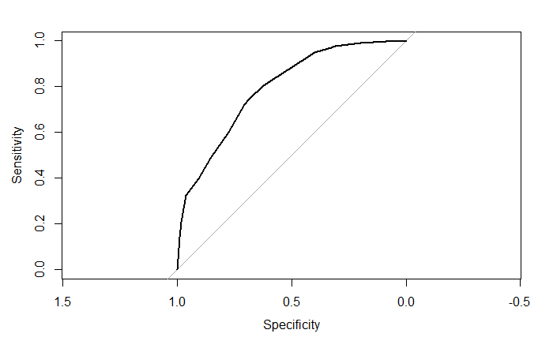

```r
plot.roc(roc_hold)
```

```r
# вычисляем вероятности классов для обучающей
# выборки и записываем в объект prob_dev
prob_dev <- predict(chd, development, type="prob")
# строим график ROC-кривой для обучающей выборки
roc_dev <-plot.roc(development$response, prob_dev[,2],
                   main="График ROC-кривой для модели CHAID",
                   ci=TRUE, percent=TRUE,
                   print.auc=TRUE, col="red")
# добавляем в уже существующий график ROC-кривую
# для контрольной выборки
roc_hold <-plot.roc(holdout$response, prob_hold[,2],
                    ci=TRUE, percent=TRUE,
                    print.auc=TRUE, print.auc.x=50, print.auc.y=45,
                    col="purple", add=TRUE)
```

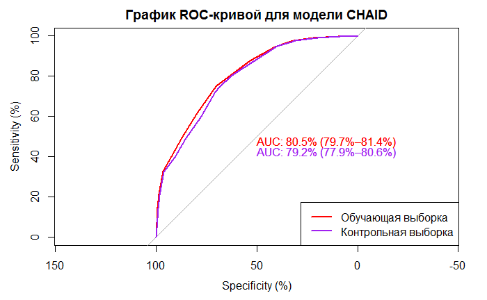

```r
# добавляем легенды
legend("bottomright", legend=c("Обучающая выборка", "Контрольная выборка"),
       col=c("red", "purple"), lwd=2)
```